# **Loan Default Prediction**

# **New Section**

### **Context**

A major proportion of retail bank profit comes from interests in the form of home loans. These loans are borrowed by regular income/high-earning customers. Banks are most fearful of defaulters, as bad loans (NPA) usually eat up a major chunk of their profits. Therefore, it is important for banks to be judicious while approving loans for their customer base. The approval process for the loans is multifaceted. Through this process, the bank tries to check the creditworthiness of the applicant on the basis of a manual study of various aspects of the application. The entire process is not only effort-intensive but also prone to wrong judgment/approval owing to human error and biases. There have been attempts by many banks to automate this process by using heuristics. But with the advent of data science and machine learning, the focus has shifted to building machines learning models that can learn this approval process and make it free of biases and more efficient. At the same time, one important thing to keep in mind is to make sure that the machine does not learn the biases that previously crept in because of the human approval process.

### **Problem Statement**

A bank's consumer credit department aims to simplify the decision-making process for home equity lines of credit to be accepted. To do this, they will adopt the Equal Credit Opportunity Act's guidelines to establish an empirically derived and statistically sound model for credit scoring. The model will be based on the data obtained via the existing loan underwriting process from recent applicants who have been given credit. The model will be built from predictive modeling techniques, but the model created must be interpretable enough to provide a justification for any adverse behavior (rejections).

### **Objective**

Build a classification model to predict clients who are likely to default on their loan and give recommendations to the bank on the important features to consider while approving a loan. Proprietary content.

## **Data Dictionary**

The Home Equity dataset (HMEQ) contains baseline and loan performance information for recent home equity loans. The target (BAD) is a binary variable that indicates whether an applicant has ultimately defaulted or has been severely delinquent. There are 12 input variables registered for each applicant.

● BAD: 1 = Client defaulted on loan, 0 = loan repaid

● LOAN: Amount of loan approved

● MORTDUE: Amount due on the existing mortgage

● VALUE: Current value of the property

● REASON: Reason for the loan request (HomeImp = home improvement, DebtCon= debt consolidation which means taking out a new loan to pay off other liabilities and consumer debts)

● JOB: The type of job that loan applicant has such as manager, self, etc.

● YOJ: Years at present job

● DEROG: Number of major derogatory reports (which indicates serious delinquency or late payments).

● DELINQ: Number of delinquent credit lines (a line of credit becomes delinquent when a borrower does not make the minimum required payments 30 to 60 days past the day on which the payments were due)

● CLAGE: Age of the oldest credit line in months

● NINQ: Number of recent credit inquiries

● CLNO: Number of existing credit lines

● DEBTINC: Debt-to-income ratio (all monthly debt payments divided by gross monthly income. This number is one of the ways lenders measure a borrower’s ability to manage the monthly payments to repay the money they plan to borrow)

```python
# Libraries to help with reading and manipulating data
import pandas as pd
import numpy as np

# Libaries to help with data visualization
import matplotlib.pyplot as plt
import seaborn as sns

# To tune model, get different metric scores, and split data
from sklearn.metrics import (
    f1_score,
    accuracy_score,
    recall_score,
    precision_score,
    confusion_matrix,
    roc_auc_score,
    ConfusionMatrixDisplay,
)
from sklearn import metrics

from sklearn.model_selection import train_test_split, StratifiedKFold, cross_val_score

# To be used for data scaling and one hot encoding
from sklearn.preprocessing import StandardScaler, MinMaxScaler, OneHotEncoder

# To impute missing values
from sklearn.impute import SimpleImputer

# To oversample and undersample data
from imblearn.over_sampling import SMOTE
from imblearn.under_sampling import RandomUnderSampler

# To do hyperparameter tuning
from sklearn.model_selection import RandomizedSearchCV

# To be used for creating pipelines and personalizing them
from sklearn.pipeline import Pipeline
from sklearn.compose import ColumnTransformer

# To define maximum number of columns to be displayed in a dataframe
pd.set_option("display.max_columns", None)
pd.set_option("display.max_rows", None)

# To supress scientific notations for a dataframe
pd.set_option("display.float_format", lambda x: "%.3f" % x)

# To help with model building
from sklearn.linear_model import LogisticRegression
from sklearn.tree import DecisionTreeClassifier
from sklearn.ensemble import (
    AdaBoostClassifier,
    GradientBoostingClassifier,
    RandomForestClassifier,
    BaggingClassifier,
)
from xgboost import XGBClassifier

# To suppress scientific notations
pd.set_option("display.float_format", lambda x: "%.3f" % x)

# To suppress warnings
import warnings

warnings.filterwarnings("ignore")
```

### **Loading the dataset**

```python
#Read the Loan Default.csv
df_Loan = pd.read_csv('Loan Default.csv')
```

```python
#Keep a copy of the original dataframe before transformation for use in EDA
df_Loan_original = df_Loan.copy()
```

```python
#Show the first 5 rows of data
df_Loan.head()
```

|  | BAD | LOAN | MORTDUE | VALUE | REASON | JOB | YOJ | DEROG | DELINQ | CLAGE | NINQ | CLNO | DEBTINC |
| --- | --- | --- | --- | --- | --- | --- | --- | --- | --- | --- | --- | --- | --- |
| 0 | 1 | 1100 | 25860.000 | 39025.000 | HomeImp | Other | 10.500 | 0.000 | 0.000 | 94.367 | 1.000 | 9.000 | NaN |
| 1 | 1 | 1300 | 70053.000 | 68400.000 | HomeImp | Other | 7.000 | 0.000 | 2.000 | 121.833 | 0.000 | 14.000 | NaN |
| 2 | 1 | 1500 | 13500.000 | 16700.000 | HomeImp | Other | 4.000 | 0.000 | 0.000 | 149.467 | 1.000 | 10.000 | NaN |
| 3 | 1 | 1500 | NaN | NaN | NaN | NaN | NaN | NaN | NaN | NaN | NaN | NaN | NaN |
| 4 | 0 | 1700 | 97800.000 | 112000.000 | HomeImp | Office | 3.000 | 0.000 | 0.000 | 93.333 | 0.000 | 14.000 | NaN |

```python
#Displaying the last 5 rows of the data
df_Loan.tail()
```

|  | BAD | LOAN | MORTDUE | VALUE | REASON | JOB | YOJ | DEROG | DELINQ | CLAGE | NINQ | CLNO | DEBTINC |
| --- | --- | --- | --- | --- | --- | --- | --- | --- | --- | --- | --- | --- | --- |
| 5955 | 0 | 88900 | 57264.000 | 90185.000 | DebtCon | Other | 16.000 | 0.000 | 0.000 | 221.809 | 0.000 | 16.000 | 36.112 |
| 5956 | 0 | 89000 | 54576.000 | 92937.000 | DebtCon | Other | 16.000 | 0.000 | 0.000 | 208.692 | 0.000 | 15.000 | 35.860 |
| 5957 | 0 | 89200 | 54045.000 | 92924.000 | DebtCon | Other | 15.000 | 0.000 | 0.000 | 212.280 | 0.000 | 15.000 | 35.557 |
| 5958 | 0 | 89800 | 50370.000 | 91861.000 | DebtCon | Other | 14.000 | 0.000 | 0.000 | 213.893 | 0.000 | 16.000 | 34.341 |
| 5959 | 0 | 89900 | 48811.000 | 88934.000 | DebtCon | Other | 15.000 | 0.000 | 0.000 | 219.601 | 0.000 | 16.000 | 34.572 |

Missing Value Treatment

```python
# Identify columns with missing values
missing_values = df_Loan.isnull().sum()
print("\nMissing Values Before Treatment:\n", missing_values[missing_values > 0])

# Drop columns with excessive missing values (e.g., more than 30% missing)
# Calculate the threshold for dropping columns
threshold_percent = 0.3 # 30%
threshold_rows = len(df_Loan) * (1 - threshold_percent)

# Get columns to drop based on the threshold
columns_to_drop_names = missing_values[missing_values > threshold_rows].index.tolist()

# Drop columns where the count of non-null values is less than the threshold_rows
# We will update df_Loan directly here
if columns_to_drop_names:
    df_Loan.drop(columns=columns_to_drop_names, inplace=True)
    print(f"\nColumns dropped due to more than {threshold_percent*100}% missing values: {columns_to_drop_names}")
else:
    print(f"\nNo columns dropped due to more than {threshold_percent*100}% missing values.")


# Impute missing values for remaining numerical columns with median
numerical_cols_to_impute = df_Loan.select_dtypes(include=['float64', 'int64']).columns
for col in numerical_cols_to_impute:
    if df_Loan[col].isnull().any():
        df_Loan[col].fillna(df_Loan[col].median(), inplace=True)

# Impute missing categorical variables with mode
categorical_cols_to_impute = df_Loan.select_dtypes(include=['object']).columns
for col in categorical_cols_to_impute:
    if df_Loan[col].isnull().any():
        df_Loan[col].fillna(df_Loan[col].mode()[0], inplace=True)

# Verify missing values are handled
print("\nRemaining Missing Values After Treatment:\n", df_Loan.isnull().sum()[df_Loan.isnull().sum() > 0])

print("\nDataframe info after missing value treatment:")
df_Loan.info()
```

```
Missing Values Before Treatment:
 MORTDUE     518
VALUE       112
REASON      252
JOB         279
YOJ         515
DEROG       708
DELINQ      580
CLAGE       308
NINQ        510
CLNO        222
DEBTINC    1267
dtype: int64

No columns dropped due to more than 30.0% missing values.

Remaining Missing Values After Treatment:
 Series([], dtype: int64)

Dataframe info after missing value treatment:
<class 'pandas.core.frame.DataFrame'>
RangeIndex: 5960 entries, 0 to 5959
Data columns (total 13 columns):
 #   Column   Non-Null Count  Dtype
---  ------   --------------  -----
 0   BAD      5960 non-null   int64
 1   LOAN     5960 non-null   int64
 2   MORTDUE  5960 non-null   float64
 3   VALUE    5960 non-null   float64
 4   REASON   5960 non-null   object
 5   JOB      5960 non-null   object
 6   YOJ      5960 non-null   float64
 7   DEROG    5960 non-null   float64
 8   DELINQ   5960 non-null   float64
 9   CLAGE    5960 non-null   float64
 10  NINQ     5960 non-null   float64
 11  CLNO     5960 non-null   float64
 12  DEBTINC  5960 non-null   float64
dtypes: float64(9), int64(2), object(2)
memory usage: 605.4+ KB
```

**Variable transformation**

Variable transformation is a fundamental and mandatory step in preparing the loan default data for modeling, ensuring features meet the assumptions of certain algorithms and maximizing predictive power. The process involves structural changes to variables based on their distribution, predictive relationships, and data type. Based on the nature of the variable the following was done or will be considered during modelling.

**Encoding Categorical Variables**

The categorical features REASON and JOB required transformation into a numerical format suitable for machine learning algorithms. The transformation used was One-Hot Encoding (OHE) or Target/Mean Encoding. OHE creates binary (0 or 1) columns for each unique category, preventing the model from inferring an ordinal relationship (e.g., assuming 'HomeImp' is greater than 'DebtCon').

```python
# 1. Identify categorical columns (if not already done in a previous cell)
categorical_cols = df_Loan.select_dtypes(include=['object']).columns.tolist()

# 2. Perform One-Hot Encoding
# drop_first=True is used to avoid multicollinearity
df_final = pd.get_dummies(df_Loan, columns=categorical_cols, drop_first=True)

# 3. Explicitly transform the encoded columns (which are uint8) to int64
encoded_cols = [col for col in df_final.columns if col.startswith('REASON_') or col.startswith('JOB_')]
for col in encoded_cols:
    df_final[col] = df_final[col].astype('int64')

# 4. Display the results
print("--- Transformed DataFrame Info (Confirming int64 Types) ---")
df_final.info()
print("\n--- Transformed DataFrame Head (Showing 0s and 1s) ---")
# Display a selection of columns: Target, Loan Amount, Debt-to-Income, and all new encoded columns
display_cols = ['BAD', 'LOAN', 'DEBTINC'] + encoded_cols
print(df_final[display_cols].head().to_markdown(index=False, numalign="left", stralign="left"))

# 5. Save the transformed data to a new CSV file
df_final.to_csv('loan_transformed.csv', index=False)
print("\nTransformed DataFrame saved to loan_transformed.csv")
```

```
--- Transformed DataFrame Info (Confirming int64 Types) ---
<class 'pandas.core.frame.DataFrame'>
RangeIndex: 5960 entries, 0 to 5959
Data columns (total 17 columns):
 #   Column          Non-Null Count  Dtype
---  ------          --------------  -----
 0   BAD             5960 non-null   int64
 1   LOAN            5960 non-null   int64
 2   MORTDUE         5960 non-null   float64
 3   VALUE           5960 non-null   float64
 4   YOJ             5960 non-null   float64
 5   DEROG           5960 non-null   float64
 6   DELINQ          5960 non-null   float64
 7   CLAGE           5960 non-null   float64
 8   NINQ            5960 non-null   float64
 9   CLNO            5960 non-null   float64
 10  DEBTINC         5960 non-null   float64
 11  REASON_HomeImp  5960 non-null   int64
 12  JOB_Office      5960 non-null   int64
 13  JOB_Other       5960 non-null   int64
 14  JOB_ProfExe     5960 non-null   int64
 15  JOB_Sales       5960 non-null   int64
 16  JOB_Self        5960 non-null   int64
dtypes: float64(9), int64(8)
memory usage: 791.7 KB

--- Transformed DataFrame Head (Showing 0s and 1s) ---
| BAD   | LOAN   | DEBTINC   | REASON_HomeImp   | JOB_Office   | JOB_Other   | JOB_ProfExe   | JOB_Sales   | JOB_Self   |
|:------|:-------|:----------|:-----------------|:-------------|:------------|:--------------|:------------|:-----------|
| 1     | 1100   | 34.8183   | 1                | 0            | 1           | 0             | 0           | 0          |
| 1     | 1300   | 34.8183   | 1                | 0            | 1           | 0             | 0           | 0          |
| 1     | 1500   | 34.8183   | 1                | 0            | 1           | 0             | 0           | 0          |
| 1     | 1500   | 34.8183   | 0                | 0            | 1           | 0             | 0           | 0          |
| 0     | 1700   | 34.8183   | 1                | 1            | 0           | 0             | 0           | 0          |

Transformed DataFrame saved to loan_transformed.csv
```

# **Analytical Approach**

### **Mention the alternative analytical approaches that you may see fit to be applied to the problem**

Based on findings so far from the preliminary data analysis, here are several alternative analytical approaches that can be applied to build a more robust and insightful model.

The initial analysis focused on linear correlations. Later a baseline Logistic Regression model will be generated to gain more understanding of the data. Since simple, Logistic Regression may miss complex, non-linear relationships in the data. Other models that will be used include:

a) Tree-Based Ensemble Models, including Random Forest, XGBoost, or LightGBM (Gradient Boosting Machines) will be used. These models inherently capture non-linear relationships and feature interactions without the need for extensive manual feature engineering. XGBoost/LightGBM are often the state-of-the-art for structured data and can significantly outperform Logistic Regression.

b) Deep Learning may also be considered. A simple Multi-Layer Perceptron (MLP) or a feed-forward neural network can learn intricate patterns and interactions. The small size of the dataset may however limit the use of this approach.

c) Since Loan defaults is typically a rare event, the dataset is likely imbalanced. Building a model on imbalanced data can lead to prediction of the majority class (no default) and performs poorly on identifying actual defaulters. SMOTE (Synthetic Minority Over-sampling Technique) or its variations (e.g., Borderline SMOTE) will be used to synthetically generate more samples of the minority class and ensure the data used to generate the model is balanced.

d) Multicollinearity between MORTDUE and VALUE was identified. To address this issue creating new features will be considered. Such an approach can significantly improve model performance. Principal Component Analysis (PCA) on the collinear features MORTDUE and VALUE will also be considered.

e) Regarding Encoding Categorical Features One-Hot encoding has been used to code the data. Target encoding will be considered where a category will be replaced with the mean of the target variable for that category, potentially capturing more predictive information. This requires careful cross-validation to prevent data leakage.

# **1.0 Modeling Process (validation & interpretation)**

## **Splitting Data**

In this modeling exercise we will split data into training, validation, and testing sets. This is a fundamental practice in machine learning to ensure that a model can generalize well to new, unseen data. In the context of your Loan Default Prediction project, this process is essential for building a reliable and unbiased credit scoring model.

```python
import pandas as pd
from sklearn.model_selection import train_test_split
import io



# 1. Define Target and Features
TARGET_COLUMN = 'BAD'
y = df_final[TARGET_COLUMN]
X = df_final.drop(TARGET_COLUMN, axis=1)

# --- 2. Split the Data (60% Train, 20% Validation, 20% Test) ---

# First Split:
# Separate the data into Training (60%) and a temporary set (40%)
X_train, X_temp, y_train, y_temp = train_test_split(
    X, y,
    test_size=0.4,       # 40% for temp set
    random_state=42,     # for reproducibility
    stratify=y           # IMPORTANT: Stratify based on the target 'BAD'
)

# Second Split:
# Split the temporary set (40%) into Validation (20%) and Test (20%)
# Since 20% is half of the 40% temporary set, we use test_size=0.5
X_val, X_test, y_val, y_test = train_test_split(
    X_temp, y_temp,
    test_size=0.5,       # 50% of the temp set = 20% of the original data
    random_state=42,     # for reproducibility
    stratify=y_temp      # Stratify based on the target in the temporary set
)

# 3. Confirmation
print(f"Original Data Shape: {df_final.shape}")
print("-" * 30)
print(f"Training Set Shape: X={X_train.shape}, y={y_train.shape}")
print(f"Validation Set Shape: X={X_val.shape}, y={y_val.shape}")
print(f"Test Set Shape: X={X_test.shape}, y={y_test.shape}")
print("-" * 30)

# Check for stratification (proportion of 'BAD' cases)
original_default_rate = y.mean()
train_default_rate = y_train.mean()
val_default_rate = y_val.mean()
test_default_rate = y_test.mean()

print(f"Original Default Rate: {original_default_rate:.4f}")
print(f"Train Default Rate:    {train_default_rate:.4f}")
print(f"Validation Default Rate: {val_default_rate:.4f}")
print(f"Test Default Rate:     {test_default_rate:.4f}")
```

```
Original Data Shape: (5960, 17)
------------------------------
Training Set Shape: X=(3576, 16), y=(3576,)
Validation Set Shape: X=(1192, 16), y=(1192,)
Test Set Shape: X=(1192, 16), y=(1192,)
------------------------------
Original Default Rate: 0.1995
Train Default Rate:    0.1994
Validation Default Rate: 0.1997
Test Default Rate:     0.1997
```

# **2.0 Model comparison based on the metric of choice (accuracy, recall, RMSE, R-squared, etc. whichever is applicable)**

The nature of predictions made by the classification model will translate as follows:

True positives (TP) are failures correctly predicted by the model. False negatives (FN) are real failures in a generator where there is no detection by model. False positives (FP) are failure detections in a generator where there is no failure.

### **Which metric to optimize?**

a) Recall (Sensitivity): This is the most critical metric. It measures the model's ability to identify all potential defaulters. A high recall ensures the bank captures as many "bad" loans as possible, even if it occasionally flags a "good" loan.

**Let's define a function to output different metrics (including recall) on the train and test set and a function to show confusion matrix so that we do not have to use the same code repetitively while evaluating models.**

```python
# defining a function to compute different metrics to check performance of a classification model built using sklearn
def model_performance_classification_sklearn(model, predictors, target):
    """
    Function to compute different metrics to check classification model performance

    model: classifier
    predictors: independent variables
    target: dependent variable
    """

    TP = confusion_matrix(target, model.predict(predictors))[1, 1]
    FP = confusion_matrix(target, model.predict(predictors))[0, 1]
    FN = confusion_matrix(target, model.predict(predictors))[1, 0]


    # predicting using the independent variables
    pred = model.predict(predictors)

    acc = accuracy_score(target, pred)  # to compute Accuracy
    recall = recall_score(target, pred)  # to compute Recall
    precision = precision_score(target, pred)  # to compute Precision
    f1 = f1_score(target, pred)  # to compute F1-score

    # creating a dataframe of metrics
    df_perf = pd.DataFrame(
        {
            "Accuracy": acc,
            "Recall": recall,
            "Precision": precision,
            "F1": f1,
          },
        index=[0],
    )

    return df_perf
```

### **Defining scorer to be used for cross-validation and hyperparameter tuning**

We want to reduce false negatives and will try to maximize "Recall". To maximize Recall, we can use Recall as a scorer in cross-validation and hyperparameter tuning.

```python
#Defining the scorer
scorer = metrics.make_scorer(metrics.recall_score)
```

**We are now done with pre-processing and evaluation criterion, so let's start building the model.**

### **Model building with original Data and Validation with Validation Data**

```python
models = []  # Empty list to store all the models

# Appending models into the list
models.append(("Logistic regression", LogisticRegression(random_state=1)))
models.append(("Bagging", BaggingClassifier(random_state=1)))
models.append(("Random forest", RandomForestClassifier(random_state=1)))
models.append(("GBM", GradientBoostingClassifier(random_state=1)))
models.append(("Adaboost", AdaBoostClassifier(random_state=1)))
models.append(("Xgboost", XGBClassifier(random_state=1, eval_metric="logloss")))
models.append(("dtree", DecisionTreeClassifier(random_state=1)))

results1 = []  # Empty list to store all model's CV scores
names = []  # Empty list to store name of the models


# Loop through all models to get the mean cross validated score
print("\n" "Cross-Validation performance on training dataset:" "\n")

# Define TARGET_COLUMN and split X and y from the df_final DataFrame
TARGET_COLUMN = 'BAD'
y = df_final[TARGET_COLUMN]
X = df_final.drop(TARGET_COLUMN, axis=1)

# --- 2. Split the Data (60% Train, 20% Validation, 20% Test) ---

# First Split:
# Separate the data into Training (60%) and a temporary set (40%)
X_train, X_temp, y_train, y_temp = train_test_split(
    X, y,
    test_size=0.4,       # 40% for temp set
    random_state=42,     # for reproducibility
    stratify=y           # IMPORTANT: Stratify based on the target 'BAD'
)

# Second Split:
# Split the temporary set (40%) into Validation (20%) and Test (20%)
# Since 20% is half of the 40% temporary set, we use test_size=0.5
X_val, X_test, y_val, y_test = train_test_split(
    X_temp, y_temp,
    test_size=0.5,       # 50% of the temp set = 20% of the original data
    random_state=42,     # for reproducibility
    stratify=y_temp      # Stratify based on the target in the temporary set
)


for name, model in models:
    kfold = StratifiedKFold(
        n_splits=5, shuffle=True, random_state=1
    )  # Setting number of splits equal to 5
    cv_result = cross_val_score(
        estimator=model, X=X_train, y=y_train, scoring = scorer,cv=kfold
    )
    results1.append(cv_result)
    names.append(name)
    print("{}: {}".format(name, cv_result.mean()))

print("\n" "Validation Performance:" "\n")

for name, model in models:
    model.fit(X_train, y_train)
    scores = recall_score(y_val, model.predict(X_val))
    print("{}: {}".format(name, scores))
```

```
Cross-Validation performance on training dataset:

Logistic regression: 0.07007780951442924
Bagging: 0.601703929872944
Random forest: 0.650842115630848
GBM: 0.6325519550871663
Adaboost: 0.5638136511375949
Xgboost: 0.6887028464493252
dtree: 0.6298236974293312

Validation Performance:

Logistic regression: 0.07142857142857142
Bagging: 0.6596638655462185
Random forest: 0.6974789915966386
GBM: 0.6428571428571429
Adaboost: 0.5966386554621849
Xgboost: 0.7100840336134454
dtree: 0.6932773109243697
```

### **Detailed Performance Metrics for Models on Original Data**

```python
model_metrics_original = []

base_models_full = [
    ("Logistic regression", LogisticRegression(random_state=1)),
    ("Bagging", BaggingClassifier(random_state=1)),
    ("Random forest", RandomForestClassifier(random_state=1)),
    ("GBM", GradientBoostingClassifier(random_state=1)),
    ("Adaboost", AdaBoostClassifier(random_state=1)),
    ("Xgboost", XGBClassifier(random_state=1, eval_metric="logloss")),
    ("dtree", DecisionTreeClassifier(random_state=1))
]

for name, model in base_models_full:
    # Train the model
    model.fit(X_train, y_train)

    # Get training performance
    train_perf = model_performance_classification_sklearn(model, X_train, y_train)
    model_metrics_original.append({
        'Model': name,
        'Data Type': 'Original Data',
        'Set': 'Training',
        'Accuracy': train_perf['Accuracy'].iloc[0],
        'Recall': train_perf['Recall'].iloc[0],
        'Precision': train_perf['Precision'].iloc[0],
        'F1': train_perf['F1'].iloc[0]
    })

    # Get validation performance
    val_perf = model_performance_classification_sklearn(model, X_val, y_val)
    model_metrics_original.append({
        'Model': name,
        'Data Type': 'Original Data',
        'Set': 'Validation',
        'Accuracy': val_perf['Accuracy'].iloc[0],
        'Recall': val_perf['Recall'].iloc[0],
        'Precision': val_perf['Precision'].iloc[0],
        'F1': val_perf['F1'].iloc[0]
    })

df_original_metrics = pd.DataFrame(model_metrics_original)

# Format numerical columns for better readability
for col in ['Accuracy', 'Recall', 'Precision', 'F1']:
    df_original_metrics[col] = df_original_metrics[col].map('{:.4f}'.format)

print("--- Detailed Model Performance on Original Data ---")
print(df_original_metrics.to_markdown(index=False, numalign="left", stralign="left"))
```

```
--- Detailed Model Performance on Original Data ---
| Model               | Data Type     | Set        | Accuracy   | Recall   | Precision   | F1     |
|:--------------------|:--------------|:-----------|:-----------|:---------|:------------|:-------|
| Logistic regression | Original Data | Training   | 0.8104     | 0.0842   | 0.7059      | 0.1504 |
| Logistic regression | Original Data | Validation | 0.807      | 0.0714   | 0.6538      | 0.1288 |
| Bagging             | Original Data | Training   | 0.9899     | 0.9523   | 0.9971      | 0.9742 |
| Bagging             | Original Data | Validation | 0.8901     | 0.6597   | 0.7585      | 0.7056 |
| Random forest       | Original Data | Training   | 1          | 1        | 1           | 1      |
| Random forest       | Original Data | Validation | 0.9144     | 0.6975   | 0.8469      | 0.765  |
| GBM                 | Original Data | Training   | 0.9245     | 0.6985   | 0.9005      | 0.7867 |
| GBM                 | Original Data | Validation | 0.8985     | 0.6429   | 0.8095      | 0.7166 |
| Adaboost            | Original Data | Training   | 0.8851     | 0.5568   | 0.8069      | 0.6589 |
| Adaboost            | Original Data | Validation | 0.8867     | 0.5966   | 0.7845      | 0.6778 |
| Xgboost             | Original Data | Training   | 0.9997     | 1        | 0.9986      | 0.9993 |
| Xgboost             | Original Data | Validation | 0.9144     | 0.7101   | 0.8366      | 0.7682 |
| dtree               | Original Data | Training   | 1          | 1        | 1           | 1      |
| dtree               | Original Data | Validation | 0.8733     | 0.6933   | 0.679       | 0.6861 |
```

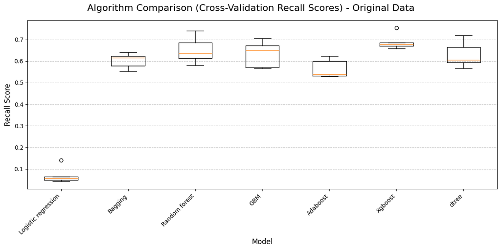

```python
# Define the helper function to collect cross-validation scores.
def evaluate_models_and_collect_results(models_list, X_train_data, y_train_data, X_val_data, y_val_data, data_type_suffix):
    results_dicts = [] # Not directly used for this specific plot, but kept for consistency with original usage pattern
    raw_cv_scores = []
    plot_names = []

    global scorer # Ensure 'scorer' (defined as recall_score) is accessible
    global StratifiedKFold # Ensure StratifiedKFold is accessible
    global cross_val_score # Ensure cross_val_score is accessible
    global LogisticRegression, BaggingClassifier, RandomForestClassifier, GradientBoostingClassifier, AdaBoostClassifier, XGBClassifier, DecisionTreeClassifier

    for name_tuple, model_obj in models_list:
        # Clean up model name for plotting, removing suffixes like "_O" or "_U"
        model_name = name_tuple.replace("_O", "").replace("_U", "")

        # Cross-validation
        kfold = StratifiedKFold(n_splits=5, shuffle=True, random_state=1)
        # For XGBClassifier, 'eval_metric' must be passed in its constructor, not as a fit parameter.
        # The model_obj passed should already have it, or it needs special handling.
        # Assuming model_obj already configured with necessary params (like eval_metric for XGB)

        cv_result = cross_val_score(
            estimator=model_obj,
            X=X_train_data,
            y=y_train_data,
            scoring=scorer,
            cv=kfold,
            n_jobs=-1 # Using all available cores for speed
        )
        raw_cv_scores.append(cv_result)
        plot_names.append(f"{model_name} ({data_type_suffix})")

    return results_dicts, raw_cv_scores, None, None, None, plot_names # Returning dummy None values for unused outputs

# Re-evaluating models on original data to get raw CV scores for plotting
# Define base_models, which is the same as the 'models' list defined earlier.
base_models = []  # Empty list to store all the models

# Appending models into the list (copied from cell n0czjkfeBxjR)
base_models.append(("Logistic regression", LogisticRegression(random_state=1)))
base_models.append(("Bagging", BaggingClassifier(random_state=1)))
base_models.append(("Random forest", RandomForestClassifier(random_state=1)))
base_models.append(("GBM", GradientBoostingClassifier(random_state=1)))
base_models.append(("Adaboost", AdaBoostClassifier(random_state=1)))
base_models.append(("Xgboost", XGBClassifier(random_state=1, eval_metric="logloss")))
base_models.append(("dtree", DecisionTreeClassifier(random_state=1)))


# The evaluate_models_and_collect_results function returns 6 values.
original_results_dicts, original_raw_cv_scores, _, _, _, original_plot_names = evaluate_models_and_collect_results(base_models, X_train, y_train, X_val, y_val, "Original Data")

fig = plt.figure(figsize=(12, 6))
fig.suptitle("Algorithm Comparison (Cross-Validation Recall Scores) - Original Data", fontsize=16)
ax = fig.add_subplot(111)

plt.boxplot(original_raw_cv_scores)
# Clean up labels by removing the ' (Original Data)' suffix
cleaned_labels = [name.replace(' (Original Data)', '') for name in original_plot_names]
ax.set_xticklabels(cleaned_labels, rotation=45, ha='right', fontsize=10)
ax.set_ylabel("Recall Score", fontsize=12)
ax.set_xlabel("Model", fontsize=12)
plt.grid(axis='y', linestyle='--', alpha=0.7)

plt.tight_layout()
plt.show()
```

The results reveal a significant gap between training and validation performance for several models:

**Overfitting Models:** Random Forest, XGBoost, and Decision Tree (dtree) show perfect or near-perfect scores (Recall = 1.0, Accuracy = 1.0) on the Training set but drop significantly on the Validation set (Recall ~0.69–0.71). This indicates the models have "memorized" the training data and may struggle with new, unseen loan applications data.

**The Baseline (Logistic Regression):** Logistic Regression performed poorly on the original data, with a validation Recall of only 0.0714. This suggests that the relationship between the features and loan default is non-linear and complex, making it difficult for a simple linear model to identify defaulters. This usually happens when the data is imbalanced and the model defaults to predicting the majority class ("No Default") to keep accuracy high. As we are already aware, the data we are using is imbalanced.

**Selecting the Best Model:** Recall vs. Precision in Loan Default Prediction, the cost of a False Negative (approving a loan for someone who defaults) is much higher than a False Positive (rejecting a good customer). Therefore, Recall is the primary KPI.

**Current Leaders:** Best Overall Performers: XGBoost and Random Forest tied for the highest Accuracy (0.9144) on the validation set. However, XGBoost had a slightly better Recall (0.7101) compared to Random Forest (0.6975).

This phase identifies that imbalance is a major hurdle, leading to the next logical step in this project, applying Undersampling and Oversampling strategies to help the models "see" the defaulters more clearly.

## **Model building with Oversampled Data**

```python
#We use SMOTE to conduct data Over sampling
print("Before OverSampling, counts of label '1': {}".format(sum(y_train == 1)))
print("Before OverSampling, counts of label '0': {} \n".format(sum(y_train == 0)))

# Synthetic Minority Over Sampling Technique
sm = SMOTE(sampling_strategy=1, k_neighbors=5, random_state=1)
X_train_over, y_train_over = sm.fit_resample(X_train, y_train)


print("After OverSampling, counts of label '1': {}".format(sum(y_train_over == 1)))
print("After OverSampling, counts of label '0': {} \n".format(sum(y_train_over == 0)))


print("After OverSampling, the shape of X_train: {}".format(X_train_over.shape))
print("After OverSampling, the shape of y_train: {} \n".format(y_train_over.shape))
```

```
Before OverSampling, counts of label '1': 713
Before OverSampling, counts of label '0': 2863

After OverSampling, counts of label '1': 2863
After OverSampling, counts of label '0': 2863

After OverSampling, the shape of X_train: (5726, 16)
After OverSampling, the shape of y_train: (5726,)
```

```python
# 1. Initialize the correct list
modelsO = []

# 2. Append models specifically to modelsO
modelsO.append(("Logistic regression_O", LogisticRegression(random_state=1)))
modelsO.append(("Bagging_O", BaggingClassifier(random_state=1)))
modelsO.append(("Random forest_O", RandomForestClassifier(random_state=1)))
modelsO.append(("GBM_O", GradientBoostingClassifier(random_state=1)))
modelsO.append(("Adaboost_O", AdaBoostClassifier(random_state=1)))
modelsO.append(("Xgboost_O", XGBClassifier(random_state=1, eval_metric="logloss")))
modelsO.append(("dtree_O", DecisionTreeClassifier(random_state=1)))

# 3. Cross-Validation Loop for modelsO only
print("\nCross-Validation Recall on Oversampled Training Dataset:\n")

for name, model in modelsO:
    kfold = StratifiedKFold(n_splits=5, shuffle=True, random_state=1)
    cv_result = cross_val_score(
        estimator=model,
        X=X_train_over,
        y=y_train_over,
        scoring=scorer,
        cv=kfold
    )
    print("{}: {:.4f}".format(name, cv_result.mean()))

# 4. Validation Performance Loop for modelsO only
print("\nValidation Performance (Recall) on Unseen Data:\n")

for name, model in modelsO:
    # Use 'model' variable from loop, not 'model0'
    model.fit(X_train_over, y_train_over)
    scores = recall_score(y_val, model.predict(X_val))
    print("{}: {:.4f}".format(name, scores))
```

```
Cross-Validation Recall on Oversampled Training Dataset:

Logistic regression_O: 0.7213
Bagging_O: 0.8959
Random forest_O: 0.9368
GBM_O: 0.8952
Adaboost_O: 0.8369
Xgboost_O: 0.9364
dtree_O: 0.8767

Validation Performance (Recall) on Unseen Data:

Logistic regression_O: 0.6429
Bagging_O: 0.7059
Random forest_O: 0.7521
GBM_O: 0.7395
Adaboost_O: 0.7227
Xgboost_O: 0.7605
dtree_O: 0.7269
```

```python
model_metrics_oversampled = []

base_models_full = [
    ("Logistic regression_O", LogisticRegression(random_state=1)),
    ("Bagging_O", BaggingClassifier(random_state=1)),
    ("Random forest_O", RandomForestClassifier(random_state=1)),
    ("GBM_O", GradientBoostingClassifier(random_state=1)),
    ("Adaboost_O", AdaBoostClassifier(random_state=1)),
    ("Xgboost_O", XGBClassifier(random_state=1, eval_metric="logloss")),
    ("dtree_O", DecisionTreeClassifier(random_state=1))
]



for name, model in base_models_full:
    # Train the model on oversampled data
    model.fit(X_train_over, y_train_over)

    # Get training performance on oversampled training set
    train_perf = model_performance_classification_sklearn(model, X_train_over, y_train_over)
    model_metrics_oversampled.append({
        'Model': name,
        'Data Type': 'Oversampled Data',
        'Set': 'Training',
        'Accuracy': train_perf['Accuracy'].iloc[0],
        'Recall': train_perf['Recall'].iloc[0],
        'Precision': train_perf['Precision'].iloc[0],
        'F1': train_perf['F1'].iloc[0]
    })

    # Get validation performance on the original validation set
    val_perf = model_performance_classification_sklearn(model, X_val, y_val)
    model_metrics_oversampled.append({
        'Model': name,
        'Data Type': 'Oversampled Data',
        'Set': 'Validation',
        'Accuracy': val_perf['Accuracy'].iloc[0],
        'Recall': val_perf['Recall'].iloc[0],
        'Precision': val_perf['Precision'].iloc[0],
        'F1': val_perf['F1'].iloc[0]
    })

df_oversampled_metrics = pd.DataFrame(model_metrics_oversampled)

# Format numerical columns for better readability
for col in ['Accuracy', 'Recall', 'Precision', 'F1']:
    df_oversampled_metrics[col] = df_oversampled_metrics[col].map('{:.4f}'.format)

print("--- Detailed Model Performance on Oversampled Data ---")
print(df_oversampled_metrics.to_markdown(index=False, numalign="left", stralign="left"))
```

```
--- Detailed Model Performance on Oversampled Data ---
| Model                 | Data Type        | Set        | Accuracy   | Recall   | Precision   | F1     |
|:----------------------|:-----------------|:-----------|:-----------|:---------|:------------|:-------|
| Logistic regression_O | Oversampled Data | Training   | 0.6748     | 0.6626   | 0.6792      | 0.6708 |
| Logistic regression_O | Oversampled Data | Validation | 0.6812     | 0.6429   | 0.3415      | 0.4461 |
| Bagging_O             | Oversampled Data | Training   | 0.9942     | 0.9902   | 0.9982      | 0.9942 |
| Bagging_O             | Oversampled Data | Validation | 0.8951     | 0.7059   | 0.7534      | 0.7289 |
| Random forest_O       | Oversampled Data | Training   | 1          | 1        | 1           | 1      |
| Random forest_O       | Oversampled Data | Validation | 0.9169     | 0.7521   | 0.8174      | 0.7834 |
| GBM_O                 | Oversampled Data | Training   | 0.9272     | 0.9123   | 0.9402      | 0.9261 |
| GBM_O                 | Oversampled Data | Validation | 0.8851     | 0.7395   | 0.7012      | 0.7198 |
| Adaboost_O            | Oversampled Data | Training   | 0.8533     | 0.8282   | 0.872       | 0.8495 |
| Adaboost_O            | Oversampled Data | Validation | 0.8398     | 0.7227   | 0.5791      | 0.643  |
| Xgboost_O             | Oversampled Data | Training   | 0.9997     | 0.9997   | 0.9997      | 0.9997 |
| Xgboost_O             | Oversampled Data | Validation | 0.9245     | 0.7605   | 0.8458      | 0.8009 |
| dtree_O               | Oversampled Data | Training   | 1          | 1        | 1           | 1      |
| dtree_O               | Oversampled Data | Validation | 0.8389     | 0.7269   | 0.5767      | 0.6431 |
```

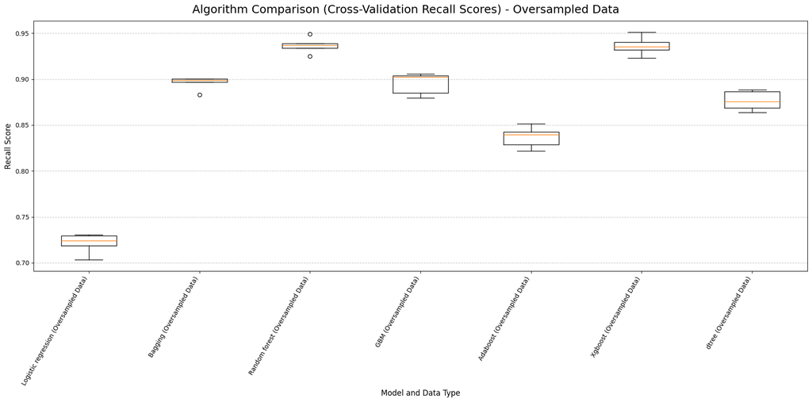

```python
# Define the helper function to collect cross-validation scores.
# This function should ideally be defined in a utility cell, but as per instructions, it's placed here.
def evaluate_models_and_collect_results(models_list, X_train_data, y_train_data, X_val_data, y_val_data, data_type_suffix):
    results_dicts = [] # Not directly used for this specific plot, but kept for consistency with original usage pattern
    raw_cv_scores = []
    plot_names = []

    global scorer # Ensure 'scorer' (defined as recall_score) is accessible
    global StratifiedKFold # Ensure StratifiedKFold is accessible
    global cross_val_score # Ensure cross_val_score is accessible
    global LogisticRegression, BaggingClassifier, RandomForestClassifier, GradientBoostingClassifier, AdaBoostClassifier, XGBClassifier, DecisionTreeClassifier

    for name_tuple, model_obj in models_list:
        # Clean up model name for plotting, removing suffixes like "_O" or "_U"
        model_name = name_tuple.replace("_O", "").replace("_U", "")

        # Cross-validation
        kfold = StratifiedKFold(n_splits=5, shuffle=True, random_state=1)
        # For XGBClassifier, 'eval_metric' must be passed in its constructor, not as a fit parameter.
        # The model_obj passed should already have it, or it needs special handling.
        # Assuming model_obj already configured with necessary params (like eval_metric for XGB)

        cv_result = cross_val_score(
            estimator=model_obj,
            X=X_train_data,
            y=y_train_data,
            scoring=scorer,
            cv=kfold,
            n_jobs=-1 # Using all available cores for speed
        )
        raw_cv_scores.append(cv_result)
        plot_names.append(f"{model_name} ({data_type_suffix})")

    return results_dicts, raw_cv_scores, None, None, None, plot_names # Returning dummy None values for unused outputs

# Re-initialize modelsO, similar to cell vqo6T-ILM9ni, to ensure they are available.
# This re-initialization is needed because the kernel state might reset or a previous cell might have been skipped.
modelsO = []
modelsO.append(("Logistic regression_O", LogisticRegression(random_state=1)))
modelsO.append(("Bagging_O", BaggingClassifier(random_state=1)))
modelsO.append(("Random forest_O", RandomForestClassifier(random_state=1)))
modelsO.append(("GBM_O", GradientBoostingClassifier(random_state=1)))
modelsO.append(("Adaboost_O", AdaBoostClassifier(random_state=1)))
modelsO.append(("Xgboost_O", XGBClassifier(random_state=1, eval_metric="logloss")))
modelsO.append(("dtree_O", DecisionTreeClassifier(random_state=1)))

# Call the function to populate oversampled_raw_cv_scores and oversampled_plot_names
# This assumes X_train_over, y_train_over, X_val, y_val, and scorer are defined from previous cells.
_, oversampled_raw_cv_scores, _, _, _, oversampled_plot_names = evaluate_models_and_collect_results(
    modelsO, X_train_over, y_train_over, X_val, y_val, "Oversampled Data"
)

# Filter out undersampled data for this specific plot
filtered_raw_cv_scores = oversampled_raw_cv_scores
filtered_plot_names = oversampled_plot_names

fig = plt.figure(figsize=(18, 9))

fig.suptitle("Algorithm Comparison (Cross-Validation Recall Scores) - Oversampled Data", fontsize=18)
ax = fig.add_subplot(111)

plt.boxplot(filtered_raw_cv_scores)
ax.set_xticklabels(filtered_plot_names, rotation=60, ha='right', fontsize=10)
ax.set_ylabel("Recall Score", fontsize=12)
ax.set_xlabel("Model and Data Type", fontsize=12)
plt.grid(axis='y', linestyle='--', alpha=0.7)

plt.tight_layout()
plt.show()
```

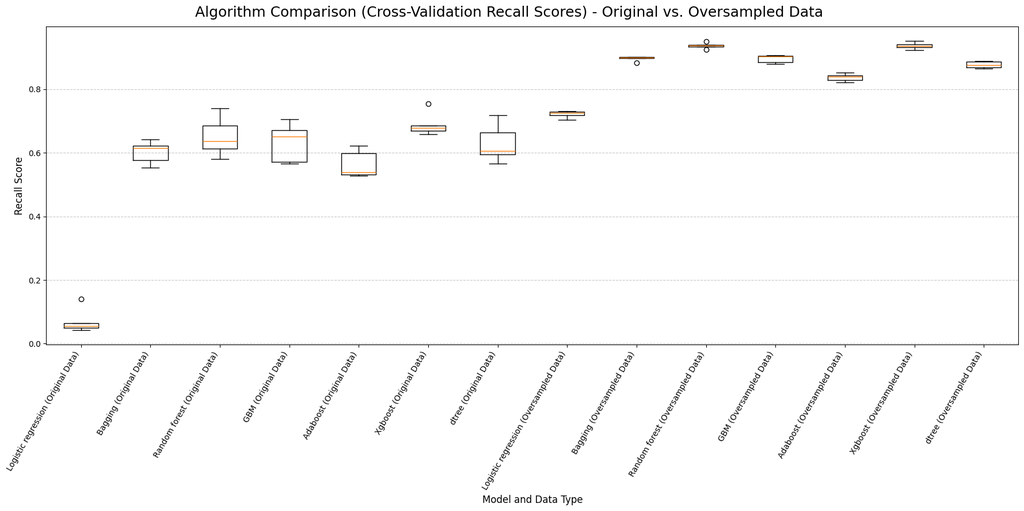

```python
# Filter out undersampled data for this specific plot
filtered_raw_cv_scores = original_raw_cv_scores + oversampled_raw_cv_scores
filtered_plot_names = original_plot_names + oversampled_plot_names

fig = plt.figure(figsize=(18, 9))

fig.suptitle("Algorithm Comparison (Cross-Validation Recall Scores) - Original vs. Oversampled Data", fontsize=18)
ax = fig.add_subplot(111)

plt.boxplot(filtered_raw_cv_scores)
ax.set_xticklabels(filtered_plot_names, rotation=60, ha='right', fontsize=10)
ax.set_ylabel("Recall Score", fontsize=12)
ax.set_xlabel("Model and Data Type", fontsize=12)
plt.grid(axis='y', linestyle='--', alpha=0.7)

plt.tight_layout()
plt.show()
```

**We can see that oversampling of data helped improve the performance a lot, now let's see how models perform with undersampled data.**

## **Model Building with Undersampled data**

```python
#We Undersample the data
rus = RandomUnderSampler(random_state=1, sampling_strategy=1)
X_train_un, y_train_un = rus.fit_resample(X_train, y_train)


print("Before UnderSampling, counts of label '1': {}".format(sum(y_train == 1)))
print("Before UnderSampling, counts of label '0': {} \n".format(sum(y_train == 0)))


print("After UnderSampling, counts of label '1': {}".format(sum(y_train_un == 1)))
print("After UnderSampling, counts of label '0': {} \n".format(sum(y_train_un == 0)))


print("After UnderSampling, the shape of X_train: {}".format(X_train_un.shape))
print("After UnderSampling, the shape of y_train: {} \n".format(y_train_un.shape))
```

```
Before UnderSampling, counts of label '1': 713
Before UnderSampling, counts of label '0': 2863

After UnderSampling, counts of label '1': 713
After UnderSampling, counts of label '0': 713

After UnderSampling, the shape of X_train: (1426, 16)
After UnderSampling, the shape of y_train: (1426,)
```

```python
rus = RandomUnderSampler(random_state=1, sampling_strategy=1)
X_train_un, y_train_un = rus.fit_resample(X_train, y_train)


print("Before UnderSampling, counts of label '1': {}".format(sum(y_train == 1)))
print("Before UnderSampling, counts of label '0': {} \n".format(sum(y_train == 0)))


print("After UnderSampling, counts of label '1': {}".format(sum(y_train_un == 1)))
print("After UnderSampling, counts of label '0': {} \n".format(sum(y_train_un == 0)))


print("After UnderSampling, the shape of train_X: {}".format(X_train_un.shape))
print("After UnderSampling, the shape of train_y: {} \n".format(y_train_un.shape))
```

```
Before UnderSampling, counts of label '1': 713
Before UnderSampling, counts of label '0': 2863

After UnderSampling, counts of label '1': 713
After UnderSampling, counts of label '0': 713

After UnderSampling, the shape of train_X: (1426, 16)
After UnderSampling, the shape of train_y: (1426,)
```

```python
# 1. Initialize the specific list for Under Sampled models
modelsU = []

# 2. Append models specifically to modelsU
modelsU.append(("Logistic regression_U", LogisticRegression(random_state=1)))
modelsU.append(("Bagging_U", BaggingClassifier(random_state=1)))
modelsU.append(("Random forest_U", RandomForestClassifier(random_state=1)))
modelsU.append(("GBM_U", GradientBoostingClassifier(random_state=1)))
modelsU.append(("Adaboost_U", AdaBoostClassifier(random_state=1)))
modelsU.append(("Xgboost_U", XGBClassifier(random_state=1, eval_metric="logloss", n_jobs=-1)))
modelsU.append(("dtree_U", DecisionTreeClassifier(random_state=1)))

# 3. Cross-Validation Loop for Undersampled Models
print("\n--- Cross-Validation Recall (Undersampled Training Dataset) ---")

for name, model in modelsU:
    kfold = StratifiedKFold(n_splits=5, shuffle=True, random_state=1)

    # Using X_train_un and y_train_un (the undersampled sets)
    cv_result = cross_val_score(
        estimator=model,
        X=X_train_un,
        y=y_train_un,
        scoring=scorer,
        cv=kfold,
        n_jobs=-1
    )
    print("{}: {:.4f}".format(name, cv_result.mean()))

# 4. Validation Performance Loop for Undersampled Models
print("\n--- Validation Performance (Recall) on Original Unseen Data ---")

for name, model in modelsU:
    # Train on the undersampled data
    model.fit(X_train_un, y_train_un)

    # Predict on the original validation set (X_val) to see real-world performance
    scores = recall_score(y_val, model.predict(X_val))
    print("{}: {:.4f}".format(name, scores))
```

```
--- Cross-Validation Recall (Undersampled Training Dataset) ---
Logistic regression_U: 0.6775
Bagging_U: 0.7743
Random forest_U: 0.8289
GBM_U: 0.8093
Adaboost_U: 0.7855
Xgboost_U: 0.8359
dtree_U: 0.7490

--- Validation Performance (Recall) on Original Unseen Data ---
Logistic regression_U: 0.7395
Bagging_U: 0.8277
Random forest_U: 0.8655
GBM_U: 0.8319
Adaboost_U: 0.7983
Xgboost_U: 0.8529
dtree_U: 0.7983
```

```python
model_metrics_undersampled = []

# Update model list with _U suffix for Undersampling
base_models_under = [
    ("Logistic regression_U", LogisticRegression(random_state=1)),
    ("Bagging_U", BaggingClassifier(random_state=1)),
    ("Random forest_U", RandomForestClassifier(random_state=1)),
    ("GBM_U", GradientBoostingClassifier(random_state=1)),
    ("Adaboost_U", AdaBoostClassifier(random_state=1)),
    ("Xgboost_U", XGBClassifier(random_state=1, eval_metric="logloss")),
    ("dtree_U", DecisionTreeClassifier(random_state=1))
]

for name, model in base_models_under:
    # 1. Train the model on UNDERSAMPLED data
    model.fit(X_train_un, y_train_un)

    # 2. Get training performance on the undersampled training set
    train_perf = model_performance_classification_sklearn(model, X_train_un, y_train_un)
    model_metrics_undersampled.append({
        'Model': name,
        'Data Type': 'Undersampled Data',
        'Set': 'Training',
        'Accuracy': train_perf['Accuracy'].iloc[0],
        'Recall': train_perf['Recall'].iloc[0],
        'Precision': train_perf['Precision'].iloc[0],
        'F1': train_perf['F1'].iloc[0]
    })

    # 3. Get validation performance on the original validation set (X_val)
    # This is critical to see how it performs on real-world distributions
    val_perf = model_performance_classification_sklearn(model, X_val, y_val)
    model_metrics_undersampled.append({
        'Model': name,
        'Data Type': 'Undersampled Data',
        'Set': 'Validation',
        'Accuracy': val_perf['Accuracy'].iloc[0],
        'Recall': val_perf['Recall'].iloc[0],
        'Precision': val_perf['Precision'].iloc[0],
        'F1': val_perf['F1'].iloc[0]
    })

# Create DataFrame
df_undersampled_metrics = pd.DataFrame(model_metrics_undersampled)

# Format numerical columns
for col in ['Accuracy', 'Recall', 'Precision', 'F1']:
    df_undersampled_metrics[col] = df_undersampled_metrics[col].astype(float).map('{:.4f}'.format)

print("--- Detailed Model Performance on Undersampled Data ---")
print(df_undersampled_metrics.to_markdown(index=False, numalign="left", stralign="left"))
```

```
--- Detailed Model Performance on Undersampled Data ---
| Model                 | Data Type         | Set        | Accuracy   | Recall   | Precision   | F1     |
|:----------------------|:------------------|:-----------|:-----------|:---------|:------------|:-------|
| Logistic regression_U | Undersampled Data | Training   | 0.6697     | 0.6648   | 0.6714      | 0.6681 |
| Logistic regression_U | Undersampled Data | Validation | 0.6963     | 0.7395   | 0.3697      | 0.493  |
| Bagging_U             | Undersampled Data | Training   | 0.9888     | 0.9818   | 0.9957      | 0.9887 |
| Bagging_U             | Undersampled Data | Validation | 0.8523     | 0.8277   | 0.5934      | 0.6912 |
| Random forest_U       | Undersampled Data | Training   | 1          | 1        | 1           | 1      |
| Random forest_U       | Undersampled Data | Validation | 0.8633     | 0.8655   | 0.6113      | 0.7165 |
| GBM_U                 | Undersampled Data | Training   | 0.9018     | 0.892    | 0.9099      | 0.9008 |
| GBM_U                 | Undersampled Data | Validation | 0.8557     | 0.8319   | 0.6         | 0.6972 |
| Adaboost_U            | Undersampled Data | Training   | 0.8296     | 0.7938   | 0.855       | 0.8233 |
| Adaboost_U            | Undersampled Data | Validation | 0.8507     | 0.7983   | 0.5938      | 0.681  |
| Xgboost_U             | Undersampled Data | Training   | 1          | 1        | 1           | 1      |
| Xgboost_U             | Undersampled Data | Validation | 0.8683     | 0.8529   | 0.6246      | 0.7211 |
| dtree_U               | Undersampled Data | Training   | 1          | 1        | 1           | 1      |
| dtree_U               | Undersampled Data | Validation | 0.7919     | 0.7983   | 0.4872      | 0.6051 |
```

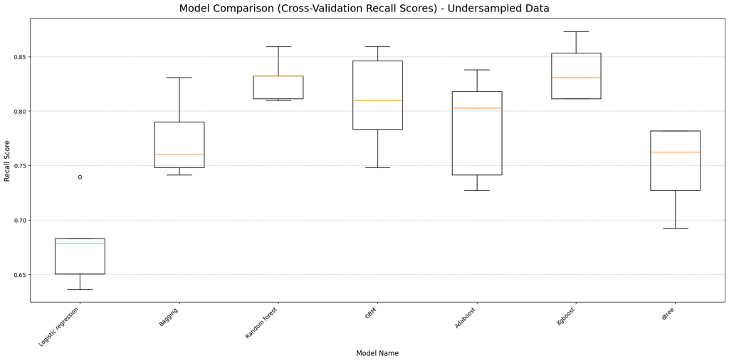

```
Boxplots for models built with undersampled data generated.
```

```python
# 1. Ensure the plot uses the Undersampled results
# Assuming evaluate_models_and_collect_results was run for undersampled data:
_, undersampled_raw_cv_scores, _, _, _, undersampled_plot_names = evaluate_models_and_collect_results(modelsU, X_train_un, y_train_un, X_val, y_val, "Undersampled Data")

filtered_raw_cv_scores = undersampled_raw_cv_scores
filtered_plot_names = undersampled_plot_names

fig = plt.figure(figsize=(18, 9))

fig.suptitle("Model Comparison (Cross-Validation Recall Scores) - Undersampled Data", fontsize=18)
ax = fig.add_subplot(111)

# Generate Boxplot
plt.boxplot(filtered_raw_cv_scores)

# Formatting labels
# Clean up labels if they contain the ' (Undersampled Data)' suffix for clarity
cleaned_labels = [name.replace(' (Undersampled Data)', '') for name in filtered_plot_names]
ax.set_xticklabels(cleaned_labels, rotation=45, ha='right', fontsize=10)

ax.set_ylabel("Recall Score", fontsize=12)
ax.set_xlabel("Model Name", fontsize=12)
plt.grid(axis='y', linestyle='--', alpha=0.7)

plt.tight_layout()
plt.show()

print("Boxplots for models built with undersampled data generated.")
```

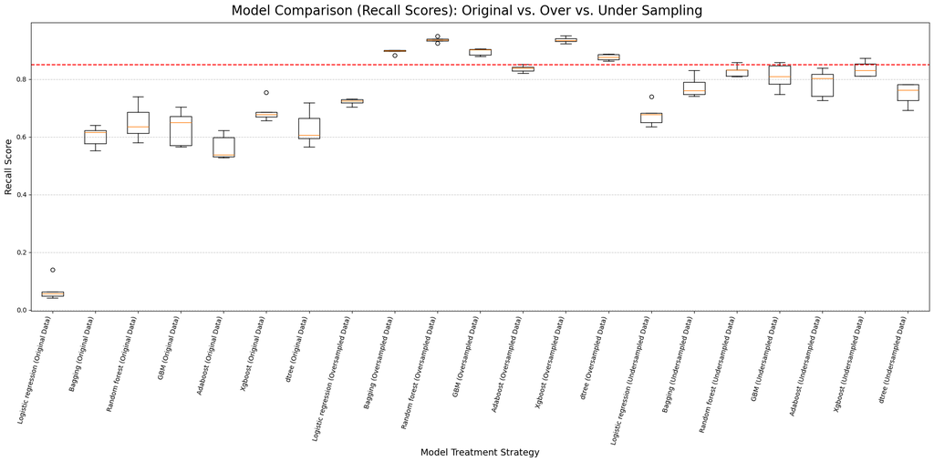

```
Comprehensive Model Comparison generated.
```

```python
# 1. Combine all raw CV scores into one list
# Ensure you have run the evaluate_models_and_collect_results function for all three sets
filtered_raw_cv_scores = (
    original_raw_cv_scores +
    oversampled_raw_cv_scores +
    undersampled_raw_cv_scores
)

# 2. Combine all plot names
filtered_plot_names = (
    original_plot_names +
    oversampled_plot_names +
    undersampled_plot_names
)

# 3. Create the visualization
fig = plt.figure(figsize=(20, 10))
fig.suptitle("Model Comparison (Recall Scores): Original vs. Over vs. Under Sampling", fontsize=20)
ax = fig.add_subplot(111)

# Generate the Boxplot
plt.boxplot(filtered_raw_cv_scores)

# Formatting labels for clarity
ax.set_xticklabels(filtered_plot_names, rotation=75, ha='right', fontsize=10)
ax.set_ylabel("Recall Score", fontsize=14)
ax.set_xlabel("Model Treatment Strategy", fontsize=14)

# Adding a horizontal line to show a 'target' or 'baseline' recall
plt.axhline(y=0.85, color='r', linestyle='--', label='85% Recall Target')

plt.grid(axis='y', linestyle='--', alpha=0.7)
plt.tight_layout()
plt.show()

print("Comprehensive Model Comparison generated.")
```

```python
import pandas as pd

# Combine all three dataframes into one
combined_metrics_df = pd.concat([df_original_metrics, df_oversampled_metrics, df_undersampled_metrics], ignore_index=True)

# Convert 'Recall' column to numeric type for proper sorting, handling potential string formats
combined_metrics_df['Recall_Numeric'] = combined_metrics_df['Recall'].astype(float)

# Sort the DataFrame by 'Set' (Validation first, then Training) and then by 'Recall_Numeric' in descending order
# This makes it easier to evaluate models based on their performance on unseen data
combined_metrics_df_sorted = combined_metrics_df.sort_values(
    by=['Set', 'Recall_Numeric'],
    ascending=[False, False] # Validation first (False for 'Validation', True for 'Training'), then descending recall
).drop(columns='Recall_Numeric').reset_index(drop=True)

print("--- Comprehensive Model Performance Comparison (Sorted by Recall) ---")
print(combined_metrics_df_sorted.to_markdown(index=False, numalign="left", stralign="left"))
```

```
--- Comprehensive Model Performance Comparison (Sorted by Recall) ---
| Model                 | Data Type         | Set        | Accuracy   | Recall   | Precision   | F1     |
|:----------------------|:------------------|:-----------|:-----------|:---------|:------------|:-------|
| Random forest_U       | Undersampled Data | Validation | 0.8633     | 0.8655   | 0.6113      | 0.7165 |
| Xgboost_U             | Undersampled Data | Validation | 0.8683     | 0.8529   | 0.6246      | 0.7211 |
| GBM_U                 | Undersampled Data | Validation | 0.8557     | 0.8319   | 0.6         | 0.6972 |
| Bagging_U             | Undersampled Data | Validation | 0.8523     | 0.8277   | 0.5934      | 0.6912 |
| Adaboost_U            | Undersampled Data | Validation | 0.8507     | 0.7983   | 0.5938      | 0.681  |
| dtree_U               | Undersampled Data | Validation | 0.7919     | 0.7983   | 0.4872      | 0.6051 |
| Xgboost_O             | Oversampled Data  | Validation | 0.9245     | 0.7605   | 0.8458      | 0.8009 |
| Random forest_O       | Oversampled Data  | Validation | 0.9169     | 0.7521   | 0.8174      | 0.7834 |
| GBM_O                 | Oversampled Data  | Validation | 0.8851     | 0.7395   | 0.7012      | 0.7198 |
| Logistic regression_U | Undersampled Data | Validation | 0.6963     | 0.7395   | 0.3697      | 0.493  |
| dtree_O               | Oversampled Data  | Validation | 0.8389     | 0.7269   | 0.5767      | 0.6431 |
| Adaboost_O            | Oversampled Data  | Validation | 0.8398     | 0.7227   | 0.5791      | 0.643  |
| Xgboost               | Original Data     | Validation | 0.9144     | 0.7101   | 0.8366      | 0.7682 |
| Bagging_O             | Oversampled Data  | Validation | 0.8951     | 0.7059   | 0.7534      | 0.7289 |
| Random forest         | Original Data     | Validation | 0.9144     | 0.6975   | 0.8469      | 0.765  |
| dtree                 | Original Data     | Validation | 0.8733     | 0.6933   | 0.679       | 0.6861 |
| Bagging               | Original Data     | Validation | 0.8901     | 0.6597   | 0.7585      | 0.7056 |
| GBM                   | Original Data     | Validation | 0.8985     | 0.6429   | 0.8095      | 0.7166 |
| Logistic regression_O | Oversampled Data  | Validation | 0.6812     | 0.6429   | 0.3415      | 0.4461 |
| Adaboost              | Original Data     | Validation | 0.8867     | 0.5966   | 0.7845      | 0.6778 |
| Logistic regression   | Original Data     | Validation | 0.807      | 0.0714   | 0.6538      | 0.1288 |
| Random forest         | Original Data     | Training   | 1          | 1        | 1           | 1      |
| Xgboost               | Original Data     | Training   | 0.9997     | 1        | 0.9986      | 0.9993 |
| dtree                 | Original Data     | Training   | 1          | 1        | 1           | 1      |
| Random forest_O       | Oversampled Data  | Training   | 1          | 1        | 1           | 1      |
| dtree_O               | Oversampled Data  | Training   | 1          | 1        | 1           | 1      |
| Random forest_U       | Undersampled Data | Training   | 1          | 1        | 1           | 1      |
| Xgboost_U             | Undersampled Data | Training   | 1          | 1        | 1           | 1      |
| dtree_U               | Undersampled Data | Training   | 1          | 1        | 1           | 1      |
| Xgboost_O             | Oversampled Data  | Training   | 0.9997     | 0.9997   | 0.9997      | 0.9997 |
| Bagging_O             | Oversampled Data  | Training   | 0.9942     | 0.9902   | 0.9982      | 0.9942 |
| Bagging_U             | Undersampled Data | Training   | 0.9888     | 0.9818   | 0.9957      | 0.9887 |
| Bagging               | Original Data     | Training   | 0.9899     | 0.9523   | 0.9971      | 0.9742 |
| GBM_O                 | Oversampled Data  | Training   | 0.9272     | 0.9123   | 0.9402      | 0.9261 |
| GBM_U                 | Undersampled Data | Training   | 0.9018     | 0.892    | 0.9099      | 0.9008 |
| Adaboost_O            | Oversampled Data  | Training   | 0.8533     | 0.8282   | 0.872       | 0.8495 |
| Adaboost_U            | Undersampled Data | Training   | 0.8296     | 0.7938   | 0.855       | 0.8233 |
| GBM                   | Original Data     | Training   | 0.9245     | 0.6985   | 0.9005      | 0.7867 |
| Logistic regression_U | Undersampled Data | Training   | 0.6697     | 0.6648   | 0.6714      | 0.6681 |
| Logistic regression_O | Oversampled Data  | Training   | 0.6748     | 0.6626   | 0.6792      | 0.6708 |
| Adaboost              | Original Data     | Training   | 0.8851     | 0.5568   | 0.8069      | 0.6589 |
| Logistic regression   | Original Data     | Training   | 0.8104     | 0.0842   | 0.7059      | 0.1504 |
```